# Intro to R Project (Model Building)

Group 4

2023-12-02

## Contributor: Chinmay Dhamapurkar

## Smart Question:Leveraging Machine Learning to Decode Urban Rental Markets: A Predictive Analytics Approach

```r
library(readxl)
data<- read_excel("C:/Users/Chinmay/OneDrive/Desktop/Intro to datascience project/cleaned_data.xlsx")
```

## Some Basic statistics

```r
print(data)
```

```
## # A tibble: 10,000 × 22
##    id         category   title body  amenities bathrooms bedrooms currency fee
##    <chr>      <chr>      <chr> <chr> <chr>     <chr>     <chr>    <chr>    <chr>
##  1 5668626895 housing/r… Stud… This… Unknown   <NA>      0        USD      No
##  2 5664597177 housing/r… Stud… This… Unknown   <NA>      1        USD      No
##  3 5668626833 housing/r… Stud… This… Unknown   1         0        USD      No
##  4 5659918074 housing/r… Stud… This… Unknown   1         0        USD      No
##  5 5668626759 housing/r… Stud… This… Unknown   <NA>      0        USD      No
##  6 5667891676 housing/r… 0 BR… **RA… Dishwash… 1         0        USD      No
##  7 5668627426 housing/r… Stud… This… Unknown   <NA>      0        USD      No
##  8 5668626687 housing/r… Stud… This… Unknown   <NA>      0        USD      No
##  9 5668610290 housing/r… Stud… This… Refriger… 1         0        USD      No
## 10 5668627023 housing/r… Stud… This… Unknown   <NA>      0        USD      No
## # ℹ 9,990 more rows
## # ℹ 13 more variables: has_photo <chr>, pets_allowed <chr>, price <dbl>,
## #   price_display <chr>, price_type <chr>, square_feet <chr>, address <chr>,
## #   cityname <chr>, state <chr>, latitude <chr>, longitude <dbl>, source <chr>,
## #   time <chr>
```

```r
str(data)
```

```
## tibble [10,000 × 22] (S3: tbl_df/tbl/data.frame)
##  $ id           : chr [1:10000] "5668626895" "5664597177" "5668626833" "5659918074" ...
##  $ category     : chr [1:10000] "housing/rent/apartment" "housing/rent/apartment" "housing/rent/apartment" "housing/rent/apartment" ...
##  $ title        : chr [1:10000] "Studio apartment 2nd St NE, Uhland Terrace NE, Washington, DC 20002" "Studio apartment 814 Schutte Road" "Studio apartment N Scott St, 14th St N, Arlington, VA 22209" "Studio apartment 1717 12th Ave" ...
##  $ body         : chr [1:10000] "This unit is located at second St NE, Uhland Terrace NE, Washington, DC 20002, Washington,20002, DCMonthly rent"| __truncated__ "This unit is located at 814 Schutte Road, Evansville,47712, INMonthly rental rates range from $425 - $445We hav"| __truncated__ "This u…
##  $ amenities    : chr [1:10000] "Unknown" "Unknown" "Unknown" "Unknown" ...
##  $ bathrooms    : chr [1:10000] NA NA "1" "1" ...
##  $ bedrooms     : chr [1:10000] "0" "1" "0" "0" ...
##  $ currency     : chr [1:10000] "USD" "USD" "USD" "USD" ...
##  $ fee          : chr [1:10000] "No" "No" "No" "No" ...
##  $ has_photo    : chr [1:10000] "Thumbnail" "Thumbnail" "Thumbnail" "Thumbnail" ...
##  $ pets_allowed : chr [1:10000] "None" "None" "None" "None" ...
##  $ price        : num [1:10000] 790 425 1390 925 880 ...
##  $ price_display: chr [1:10000] "$790" "$425" "$1,390" "$925" ...
##  $ price_type   : chr [1:10000] "Monthly" "Monthly" "Monthly" "Monthly" ...
##  $ square_feet  : chr [1:10000] "101" "106" "107" "116" ...
##  $ address      : chr [1:10000] "Unknown" "814 Schutte Rd" "Unknown" "1717 12th Avenue" ...
##  $ cityname     : chr [1:10000] "Washington" "Evansville" "Arlington" "Seattle" ...
##  $ state        : chr [1:10000] "DC" "IN" "VA" "WA" ...
##  $ latitude     : chr [1:10000] "38.9057" "37.9680" "38.8910" "47.6160" ...
##  $ longitude    : num [1:10000] -77 -87.7 -77.1 -122.3 -77.1 ...
##  $ source       : chr [1:10000] "RentLingo" "RentLingo" "RentLingo" "RentLingo" ...
##  $ time         : chr [1:10000] "43825.474710648137" "43821.512303240743" "43825.474652777782" "43817.469247685192" ...
```

```r
summary(data)
```

```
##       id              category            title               body
##  Length:10000       Length:10000       Length:10000       Length:10000
##  Class :character   Class :character   Class :character   Class :character
##  Mode  :character   Mode  :character   Mode  :character   Mode  :character
##
##
##
##   amenities          bathrooms           bedrooms           currency
##  Length:10000       Length:10000       Length:10000       Length:10000
##  Class :character   Class :character   Class :character   Class :character
##  Mode  :character   Mode  :character   Mode  :character   Mode  :character
##
##
##
##      fee             has_photo         pets_allowed           price
##  Length:10000       Length:10000       Length:10000       Min.   :  200
##  Class :character   Class :character   Class :character   1st Qu.:  945
##  Mode  :character   Mode  :character   Mode  :character   Median : 1268
##                                                           Mean   : 1483
##                                                           3rd Qu.: 1695
##                                                           Max.   :52500
##  price_display       price_type        square_feet          address
##  Length:10000       Length:10000       Length:10000       Length:10000
##  Class :character   Class :character   Class :character   Class :character
##  Mode  :character   Mode  :character   Mode  :character   Mode  :character
##
##
##
##    cityname            state             latitude           longitude
##  Length:10000       Length:10000       Length:10000       Min.   :-158.0
##  Class :character   Class :character   Class :character   1st Qu.:-101.3
##  Mode  :character   Mode  :character   Mode  :character   Median : -93.7
##                                                           Mean   : -94.1
##                                                           3rd Qu.: -81.8
##                                                           Max.   :   0.0
##     source              time
##  Length:10000       Length:10000
##  Class :character   Class :character
##  Mode  :character   Mode  :character
##
##
##
```

```r
sum(is.na(data))
```

```
## [1] 133
```

## Cleaning data by fixing the missing values.

Handling Missing Data in ‘bathrooms’ and ‘bedrooms’ Our dataset shows a small percentage of missing values in two key features: bathrooms (0.80% missing) and bedrooms (0.53% missing). The decision to address these missing values is crucial for the following reasons:

Significance of Features: Both bathrooms and bedrooms are typically important factors in determining rental prices. Therefore, removing these columns could lead to a significant loss of valuable information. Low Percentage of Missingness: Given that the missing data constitutes less than 1% for both features, it’s feasible to address these missing values without discarding the columns entirely.

```r
missing_values <- sapply(data, function(x) sum(is.na(x)))
missing_values_percentage <- (missing_values / nrow(data)) * 100
missing_data_summary <- data.frame(
  'Missing Values' = missing_values,
  'Percentage' = missing_values_percentage
)
missing_data_summary[order(-missing_values), ]
```

```
##               Missing.Values Percentage
## bathrooms                 80       0.80
## bedrooms                  53       0.53
## id                         0       0.00
## category                   0       0.00
## title                      0       0.00
## body                       0       0.00
## amenities                  0       0.00
## currency                   0       0.00
## fee                        0       0.00
## has_photo                  0       0.00
## pets_allowed               0       0.00
## price                      0       0.00
## price_display              0       0.00
## price_type                 0       0.00
## square_feet                0       0.00
## address                    0       0.00
## cityname                   0       0.00
## state                      0       0.00
## latitude                   0       0.00
## longitude                  0       0.00
## source                     0       0.00
## time                       0       0.00
```

```r
cleaned_data<-data[complete.cases(data$bathrooms,data$bedrooms), ]
sum(is.na(cleaned_data$bathrooms))
```

```
## [1] 0
```

```r
sum(is.na(cleaned_data$bedrooms))
```

```
## [1] 0
```

## In our analysis, we chose to delete the rows with missing values in the bathrooms and bedrooms columns due to the following reasons:

1)Low Percentage of Missing Data: The missing values represent a very small fraction (less than 1%) of the dataset, suggesting minimal impact on the overall data integrity.

2. Simplicity and Clarity: Deletion simplifies the dataset and avoids the potential biases or inaccuracies introduced by imputation methods.
3. Preserving Data Quality: By removing these incomplete records, we ensure that our analysis is based only on complete and reliable data.

```r
# Install and load necessary packages
#install.packages("ggplot2")
#install.packages("corrplot")
library(ggplot2)
library(corrplot)
```

## This section of the code focuses on feature engineering, specifically target encoding and feature selection.

within the context of a dataset (data) aimed at predicting rental prices. Let’s break down each step to understand the process and rationale:

1. Target Encoding for City Process: Calculation: The average rental price (price) is calculated for each city (cityname).

Creation of city_score: This average price is then assigned as a new feature, named city_score.

Merging: This new feature is merged back into the original dataset based on the cityname.

Rationale: Purpose: The idea is to capture the average price level of each city in a single number. This helps the model understand how the city’s overall rental market impacts individual rental prices.

Why Use Target Encoding?: Target encoding helps in dealing with categorical variables like cityname. It transforms these categories into a meaningful numerical format that a machine learning model can utilize effectively. It’s particularly useful when dealing with high cardinality categorical data (many unique values).

2. Target Encoding for State Process: Calculation: Similar to cities, the average rental price for each state (state) is computed.

Creation of state_score: This average is stored as state_score.

Merging: The state_score is then merged with the main dataset, keyed on state.

Rationale: Understanding Regional Trends: This captures the broader regional trends in rental prices. It helps the model to discern patterns at a state level, which might be different from city-specific trends.

3. Selecting Relevant Features Process: Selection: Features considered important for predicting rental prices are selected. These include bedrooms, bathrooms, square_feet (size of the property), latitude, longitude (geographical location), and the newly created city_score and state_score. Rationale:

Focus on Important Variables: This step is about focusing the model’s attention on variables that are most likely to influence the rental price. By selecting these features, the model can train more effectively on relevant data.

4. Preparing the Target Variable Process: Defining the Target: The variable price, which represents the rental price, is set as the target variable for prediction. Rationale:

Model’s Goal: In supervised learning, the model aims to predict an outcome or target variable. In this case, it’s the rental price. Having a clearly defined target variable is crucial for training the model. Overall, these steps are crucial for:

Data Transformation: Converting raw data into a format suitable for machine learning.

Enhancing Model Performance: By creating features like city_score and state_score, the model can understand complex patterns in the data, potentially leading to more accurate predictions.

Reducing Dimensionality: Selecting relevant features reduces the complexity of the model, which can help in avoiding overfitting and improving model performance.

```r
average_price_per_city <- aggregate(price ~ cityname, data = data, FUN = mean)
names(average_price_per_city)[2] <- "city_score"
data <- merge(data, average_price_per_city, by = "cityname", all.x = TRUE)
average_price_per_state <- aggregate(price ~ state, data = data, FUN = mean)
names(average_price_per_state)[2] <- "state_score"
data <- merge(data, average_price_per_state, by = "state", all.x = TRUE)
features <- data[c("bedrooms", "bathrooms", "square_feet", "latitude", "longitude", "city_score", "state_score")]
target <- data$price
head(features)
```

```
##   bedrooms bathrooms square_feet latitude longitude city_score state_score
## 1        1         1         728  61.1723      -150        951        1012
## 2        1         1         630  61.1723      -150        951        1012
## 3        1         1         675  61.5940      -149       1200        1012
## 4        1         1         650  61.1723      -150        951        1012
## 5        3       2.5        1400  61.5940      -149       1200        1012
## 6        3         2         950  61.1521      -150        951        1012
```

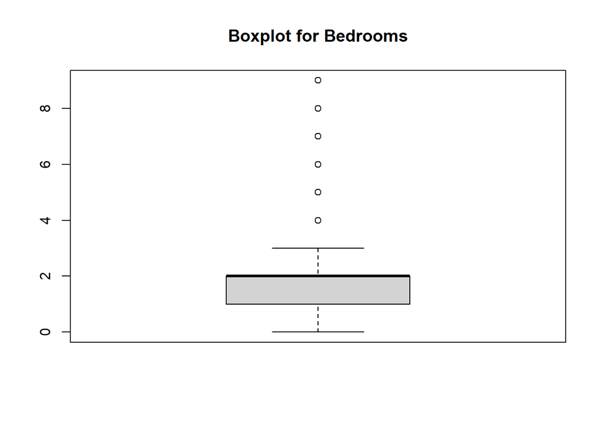

```r
summary(features)
features$bedrooms <- as.numeric(as.character(features$bedrooms))
features$bathrooms <- as.numeric(as.character(features$bathrooms))
features$square_feet <- as.numeric(as.character(features$square_feet))
features$latitude <- as.numeric(as.character(features$latitude))
str(features)
boxplot(features$bedrooms, main = "Boxplot for Bedrooms")
```

[output not shown]

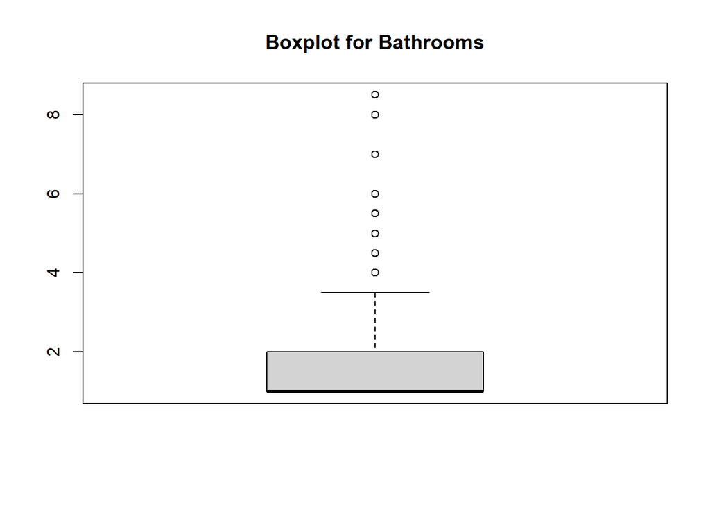

```r
boxplot(features$bathrooms, main = "Boxplot for Bathrooms")
```

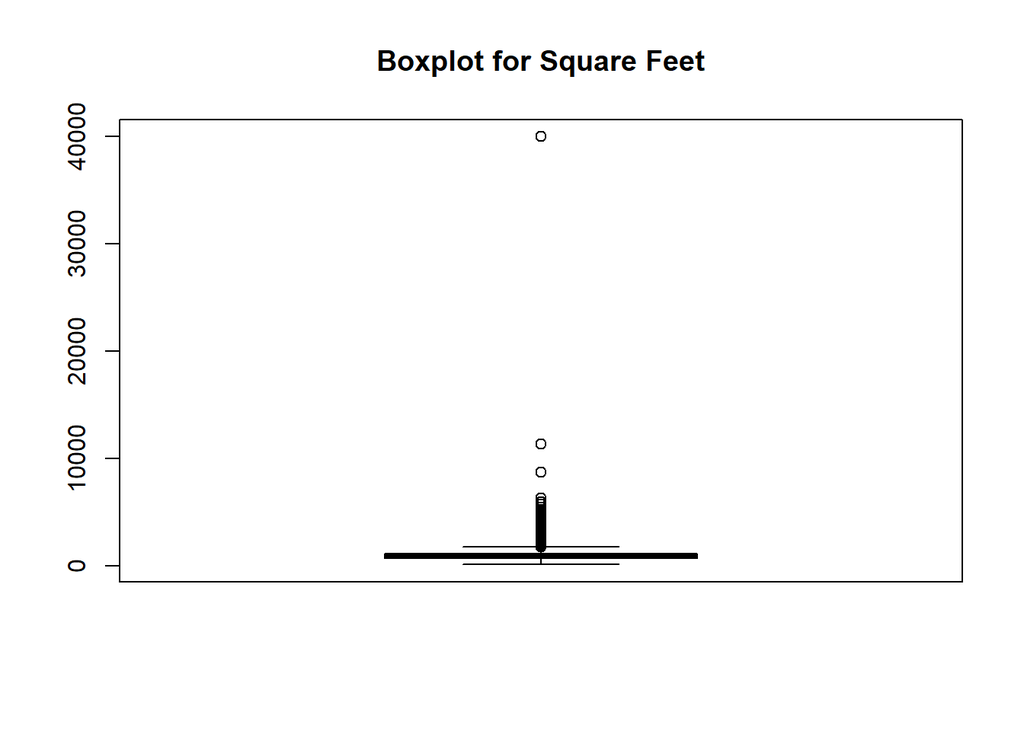

```r
boxplot(features$square_feet, main = "Boxplot for Square Feet")
```

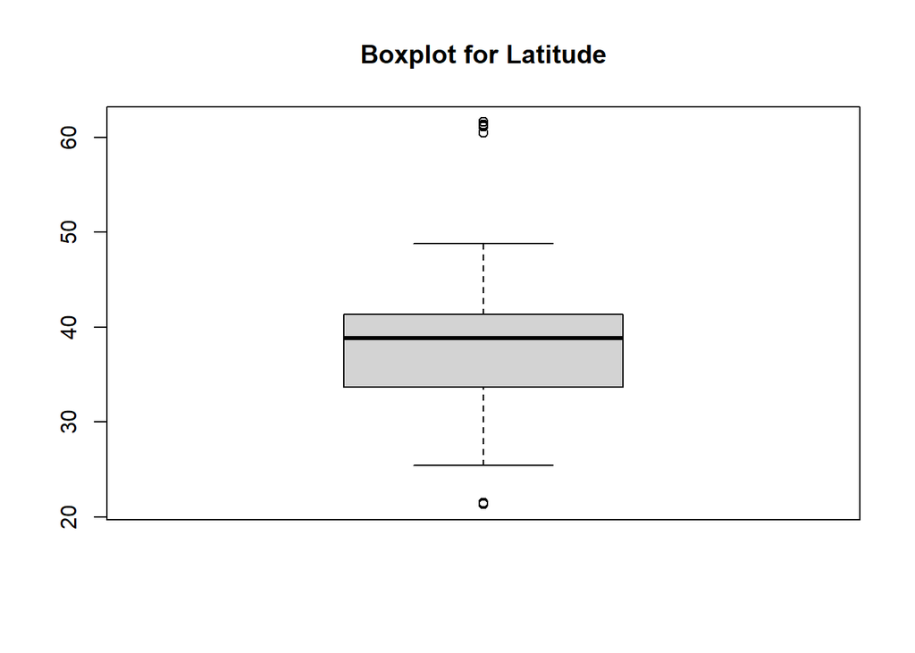

```r
boxplot(features$latitude, main = "Boxplot for Latitude")
```

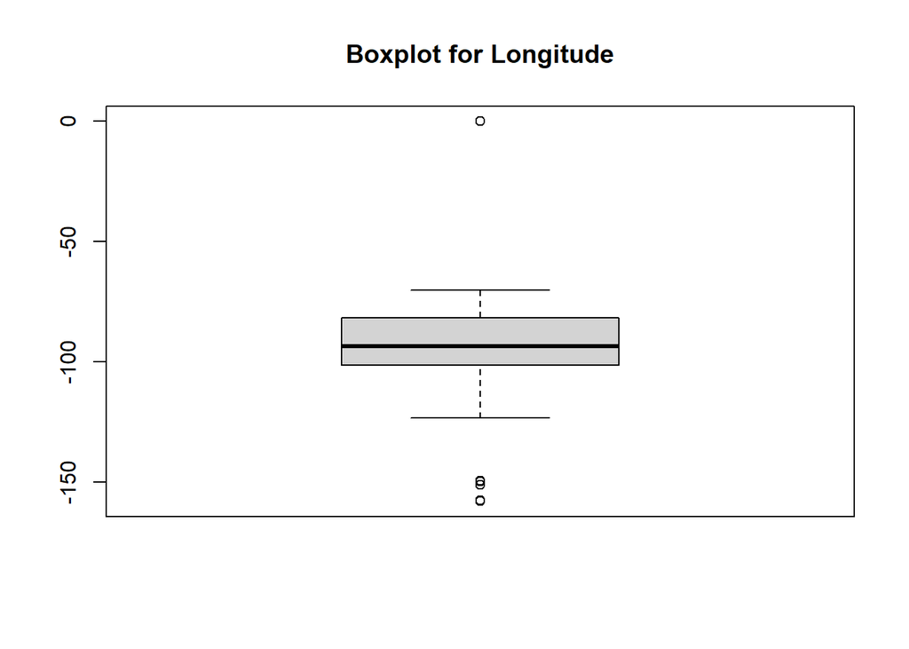

```r
boxplot(features$longitude, main = "Boxplot for Longitude")
```

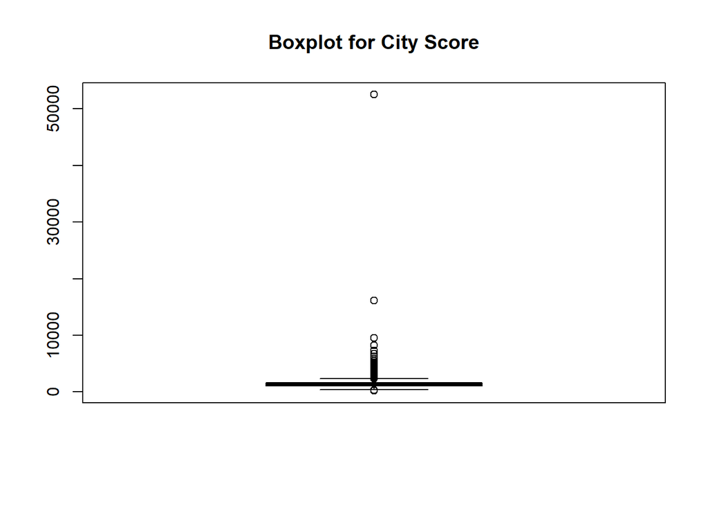

```r
boxplot(features$city_score, main = "Boxplot for City Score")
```

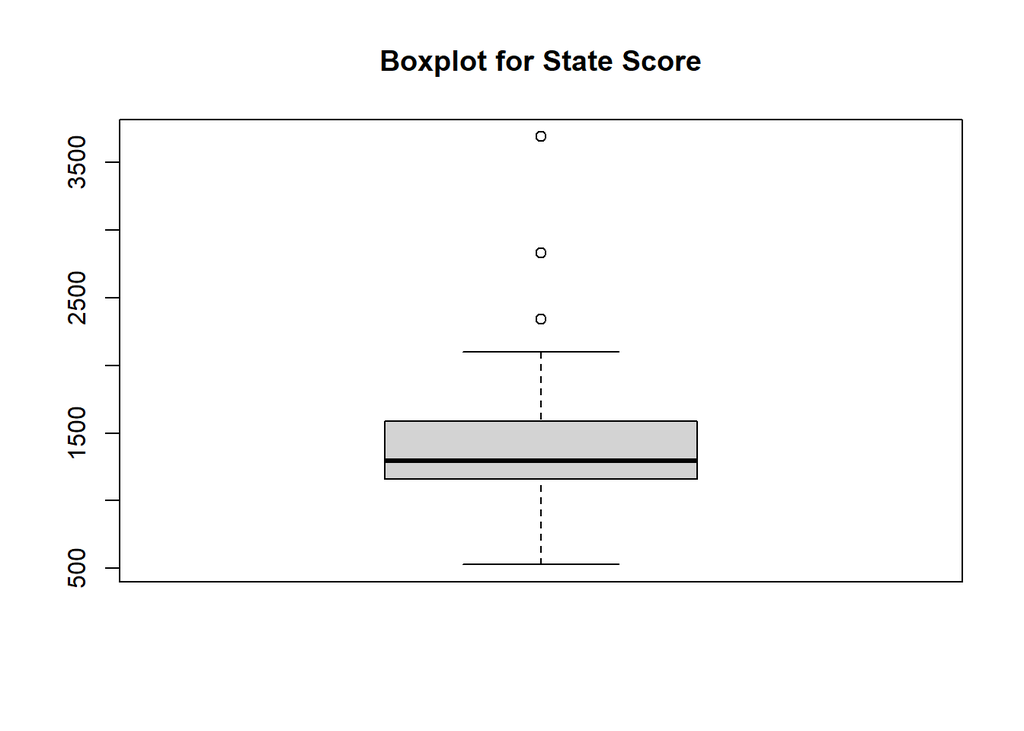

```r
boxplot(features$state_score, main = "Boxplot for State Score")
```

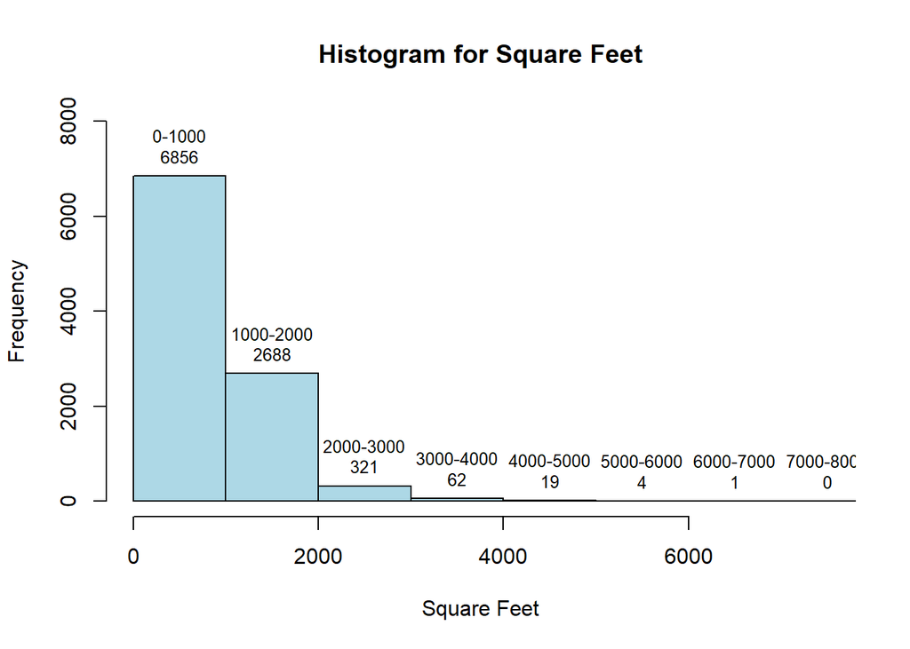

```r
hist_data <- hist(features$square_feet, main = "Histogram for Square Feet", xlab = "Square Feet", xlim = c(10, 7500), breaks = 50, ylim = c(0, 8000), plot = FALSE)
plot(hist_data, col = 'lightblue', main = "Histogram for Square Feet", xlab = "Square Feet", xlim = c(10, 7500), ylim = c(0, 8000))
mids <- hist_data$mids
counts <- hist_data$counts
for(i in seq_along(mids)) {
    label <- paste(formatC(hist_data$breaks[i], format = "f", digits = 0), "-", formatC(hist_data$breaks[i+1], format = "f", digits = 0), "\n", counts[i], sep = "")
    text(mids[i], counts[i], label, pos = 3, cex = 0.8)
}
```

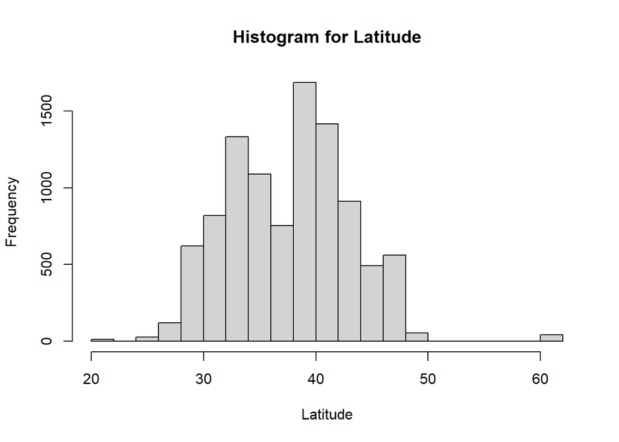

```r
hist(features$latitude, main = "Histogram for Latitude", xlab = "Latitude")
```

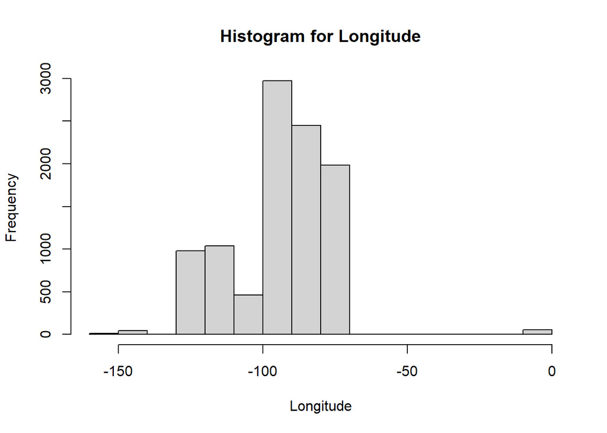

```r
hist(features$longitude, main = "Histogram for Longitude", xlab = "Longitude")
```

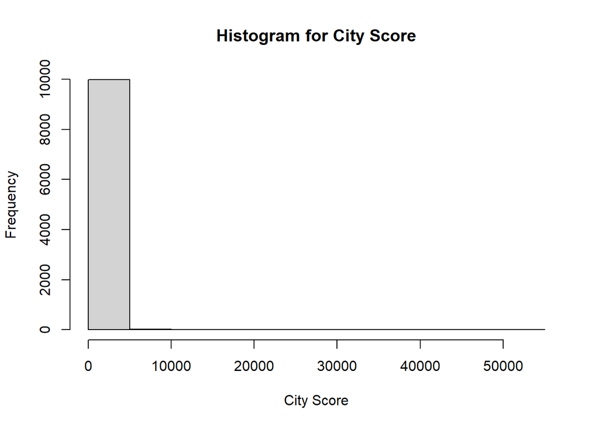

```r
hist(features$city_score, main = "Histogram for City Score", xlab = "City Score")
```

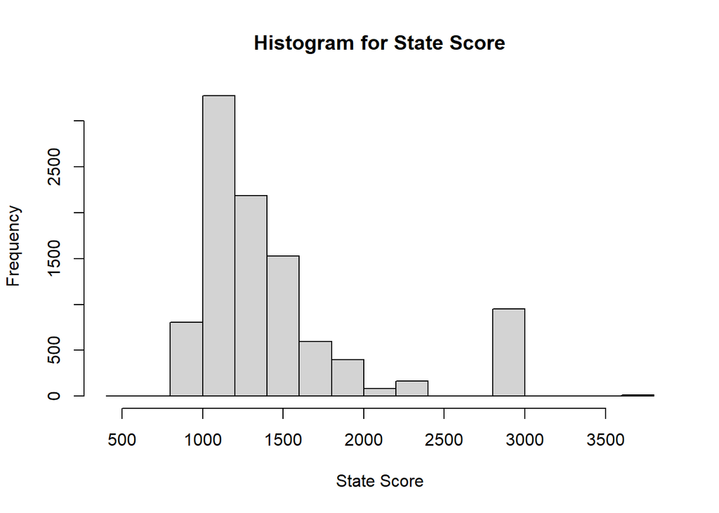

```r
hist(features$state_score, main = "Histogram for State Score", xlab = "State Score")
```

## Data Preparation and Cleaning Missing Value Check: sum(is.na(features)) calculates the total number of missing values across all features. This step is crucial for understanding the data’s cleanliness.

#Complete Case Analysis: complete_cases <- complete.cases(features, target) creates a logical vector indicating rows with no missing values in both features and target. This step is vital for ensuring the model trains on reliable, complete data.

#Data Subsetting: features_clean <- features[complete_cases, ] and target_clean <- target[complete_cases] subset the data to only include complete cases. It ensures that the models are trained on data without missing values.

#Data Splitting Setting Seed: set.seed(123) ensures reproducibility in the random sampling process. This step is important for consistent results in repeated analyses.

#Creating Training and Test Sets: The data is randomly split into training and test sets, with 80% of data used for training and the remaining 20% for testing. This split is essential for evaluating the model’s performance on unseen data.

## Model Building

Ridge and Lasso Regression: Utilizing the glmnet package, two types of regression models are built: Ridge Regression: ridge_model <- glmnet(as.matrix(train_features), train_target, alpha = 0) uses L2 regularization (penalizing the square of coefficients). alpha = 0 specifies Ridge Regression. Lasso Regression: lasso_model <- glmnet(as.matrix(train_features), train_target, alpha = 1) uses L1 regularization (penalizing the absolute value of coefficients). alpha = 1 specifies Lasso Regression. Model Evaluation Making Predictions: predict() is used to generate predictions on the test set for both models.

# R-squared Calculation:

ridge_r2 and lasso_r2 are calculated to measure the proportion of variance in the dependent variable (target) that is predictable from the independent variables (features). It’s a measure of how well unseen samples are likely to be predicted by the model.

The formula 1 - sum((test_target - predictions)^2) / sum((test_target - mean(test_target))^2) computes the R-squared value, reflecting the model’s accuracy.

## Conclusion

R-squared Values: The final output, ridge_r2 and lasso_r2, are the R-squared values for Ridge and Lasso Regression, respectively. These values quantify the models’ effectiveness in explaining the variance of the target variable. Model Comparison: Comparing ridge_r2 and lasso_r2 helps in understanding which model (Ridge or Lasso) performs better in terms of prediction accuracy on the given dataset.

```r
sum(is.na(features))
```

```
## [1] 235
```

```r
complete_cases <- complete.cases(features, target)
features_clean <- features[complete_cases, ]
target_clean <- target[complete_cases]


set.seed(123)
training_indices <- sample(1:nrow(features_clean), 0.8 * nrow(features_clean))
train_features <- features_clean[training_indices, ]
train_target <- target_clean[training_indices]
test_features <- features_clean[-training_indices, ]
test_target <- target_clean[-training_indices]
library(glmnet)
ridge_model <- glmnet(as.matrix(train_features), train_target, alpha = 0)
lasso_model <- glmnet(as.matrix(train_features), train_target, alpha = 1)

ridge_predictions <- predict(ridge_model, s = 0.01, newx = as.matrix(test_features))
lasso_predictions <- predict(lasso_model, s = 0.01, newx = as.matrix(test_features))
ridge_r2 <- 1 - sum((test_target - ridge_predictions)^2) / sum((test_target - mean(test_target))^2)
# Computing R-squared for Lasso
lasso_r2 <- 1 - sum((test_target - lasso_predictions)^2) / sum((test_target - mean(test_target))^2)
ridge_r2
```

```
## [1] 0.633
```

```r
lasso_r2
```

```
## [1] 0.627
```

## Technical and Mathematical Significance

Cross-Validation: This technique helps in assessing how the results of the statistical analysis will generalize to an independent data set and aids in preventing overfitting.

Regularization (Lambda): The lambda parameter controls the strength of the regularization penalty, which helps in managing overfitting by penalizing large coefficients in the model. Optimal lambda tuning is crucial for balancing bias-variance tradeoff.

Ridge vs Lasso: Ridge regression is good for handling multicollinearity and shrinking coefficients, while Lasso can do variable selection by shrinking some coefficients to zero.

In summary, this code implements a rigorous approach to building, optimizing, and evaluating Ridge and Lasso regression models, leveraging cross-validation to fine-tune the regularization strength and subsequently measuring model performance using R-squared. This methodology ensures robust model building by optimizing the balance between model complexity and generalization ability.

Results: After Hyperparameter tuning R-squared for Ridge: 0.63 and for Lasso: 0.62

```r
# Load necessary library
library(glmnet)
cv_ridge <- cv.glmnet(as.matrix(train_features), train_target, alpha = 0)
optimal_lambda_ridge <- cv_ridge$lambda.min
ridge_model_opt <- glmnet(as.matrix(train_features), train_target, alpha = 0, lambda = optimal_lambda_ridge)
ridge_predictions_opt <- predict(ridge_model_opt, newx = as.matrix(test_features))
cv_lasso <- cv.glmnet(as.matrix(train_features), train_target, alpha = 1)
optimal_lambda_lasso <- cv_lasso$lambda.min
lasso_model_opt <- glmnet(as.matrix(train_features), train_target, alpha = 1, lambda = optimal_lambda_lasso)
lasso_predictions_opt <- predict(lasso_model_opt, newx = as.matrix(test_features))
ridge_r2_opt <- 1 - sum((test_target - ridge_predictions_opt)^2) / sum((test_target - mean(test_target))^2)
lasso_r2_opt <- 1 - sum((test_target - lasso_predictions_opt)^2) / sum((test_target - mean(test_target))^2)
print(paste("Optimal R-squared for Ridge:", round(ridge_r2_opt, 4)))
```

```
## [1] "Optimal R-squared for Ridge: 0.6334"
```

```r
print(paste("Optimal R-squared for Lasso:", round(lasso_r2_opt, 4)))
```

```
## [1] "Optimal R-squared for Lasso: 0.6271"
```

## Why Random Forest?

Handling Overfitting: Random Forest is effective in reducing overfitting, a common problem in decision trees, by averaging multiple trees.

Feature Selection: It inherently performs feature selection and provides a good indicator of feature importance.

Handling Non-Linearity: Random Forest can handle non-linear relationships between features and the target variable.

Robust to Noise: The model is generally robust to noise and works well with large datasets.

Versatility: It’s versatile and works well for both classification and regression tasks.

## Analysis of the Result (0.76):

The R-squared value of 0.76 implies that approximately 76% of the variance in the target variable is predictable from the features. This is a relatively high value, indicating good model performance, especially in complex datasets where perfect prediction is often not feasible.

## Number of Trees:

The default number of trees in a randomForest model is 500, but this can be adjusted using the ntree parameter. More trees can improve model accuracy but also increase computational time.

## Conclusion:

The implementation of the Random Forest model in this code is a robust choice for predictive modeling, particularly due to its ability to manage complex data structures and reduce overfitting. The R-squared value of 0.76 indicates a strong model performance, demonstrating the model’s effectiveness in capturing the variability of the target variable.

```r
library(randomForest)
rf_model <- randomForest(train_features, train_target)
rf_predictions <- predict(rf_model, test_features)
rf_r2 <- 1 - sum((test_target - rf_predictions)^2) / sum((test_target - mean(test_target))^2)
print(rf_r2)
```

[output not shown]

```r
library(xgboost)
dtrain <- xgb.DMatrix(data = as.matrix(train_features), label = train_target)
dtest <- xgb.DMatrix(data = as.matrix(test_features))
params <- list(booster = "gbtree", objective = "reg:squarederror", eta = 0.3, max_depth = 6)
xgb_model <- xgb.train(params = params, data = dtrain, nrounds = 100)
xgb_predictions <- predict(xgb_model, dtest)
xgb_r2 <- 1 - sum((test_target - xgb_predictions)^2) / sum((test_target - mean(test_target))^2)

print(paste("The accuracy for the model is", xgb_r2*100))
```

[output not shown]

## XGBoost (Extreme Gradient Boosting)

## Results : 77.4% Accuracy

## How It Works:

Ensemble Learning: XGBoost is an ensemble learning method, specifically a gradient boosting framework. It builds an ensemble of decision trees sequentially, where each tree tries to correct the errors of the previous ones.

Gradient Boosting: At its core, XGBoost uses the concept of gradient boosting, where the model’s learning involves identifying and correcting for the residuals or errors of prior trees.

Objective Function: The objective function in XGBoost combines a loss function (like squared error for regression) and a regularization term (to penalize model complexity). This helps in balancing the trade-off between bias and variance.

Optimization: It uses a gradient descent algorithm to minimize the loss function. The “gradient” in gradient boosting refers to the gradient of the loss function, which guides the way to adjust the model’s predictions.

## Key Features:

Regularization: Includes L1 (Lasso) and L2 (Ridge) regularization, which helps in preventing overfitting.

Handling Missing Values and Feature Importance: Automatically handles missing values and provides an understanding of feature importance.

Efficiency: Highly efficient in terms of computation and memory usage.

## Comparison with Lasso, Ridge, and Random Forest

Lasso (L1) and Ridge (L2) Regression

Regularization Techniques: Both introduce a penalty term to the linear regression model. Lasso can shrink coefficients to zero (thus performing feature selection), while Ridge shrinks them towards zero.

Linear Models: They are fundamentally linear models and might not capture complex, non-linear relationships as effectively as tree-based methods. Random Forest

Decision Trees Ensemble: It builds multiple decision trees and merges them together to get a more accurate and stable prediction.

Reduction of Overfitting: Averages the result of multiple trees to reduce the risk of overfitting.

Non-Linear Relationships: Better at capturing non-linear relationships than linear models but doesn’t have an optimization mechanism like gradient boosting. XGBoost

Performance: Often outperforms simple ensemble methods like Random Forest when tuned properly, especially on datasets with complex patterns and relationships.

Speed and Flexibility: Faster and offers more flexibility than traditional Random Forests due to its optimization and regularization capabilities.

Generalization: Better at generalizing due to the incorporation of regularization terms.

## Best Performance of XGBoost

XGBoost’s superior performance can be attributed to its efficient use of computing resources, handling of a variety of data types, features, and relationships, and its regularization capability that helps in preventing overfitting.

The mathematical optimization at the heart of XGBoost, through gradient boosting and regularization, allows it to model complex patterns in data more effectively than traditional models.

## Conclusion

The R-squared value obtained from XGBoost will reflect its predictive accuracy. A higher R-squared value as compared to those from Lasso, Ridge, and Random Forest models would indicate a better fit to the data and an improved ability to explain the variance in the target variable. The mathematical sophistication and computational efficiency of XGBoost often make it a preferred choice for regression tasks in diverse settings.

```r
if (!require("caret")) install.packages("caret")
if (!require("randomForest")) install.packages("randomForest")
if (!require("xgboost")) install.packages("xgboost")

library(caret)
library(randomForest)
library(xgboost)
control_rf <- trainControl(method = "cv", number = 3, search = "random")
tuneGrid_rf <- expand.grid(mtry = c(2, 3, 4, 5, 6))
rf_tune <- train(train_features, train_target, method = "rf", trControl = control_rf, tuneGrid = tuneGrid_rf)
print(rf_tune$bestTune)
```

[output not shown]

```r
tuneGrid_xgb <- expand.grid(
  nrounds = c(50, 100, 150),
  eta = c(0.01, 0.05, 0.1),
  max_depth = c(3, 6, 9),
  gamma = c(0, 0.1, 0.2),
  colsample_bytree = c(0.5, 0.75, 1),
  min_child_weight = c(1, 2, 3),
  subsample = c(0.5, 0.75, 1)
)
control_xgb <- trainControl(method = "cv", number = 5, search = "random")
xgb_tune <- train(as.matrix(train_features), train_target,
                  method = "xgbTree",
                  trControl = control_xgb,
                  tuneGrid = tuneGrid_xgb)



print(xgb_tune$bestTune)
```

[output not shown]

## Why Hyperparameter Tuning:

Model Optimization: Different models and datasets respond uniquely to different hyperparameter settings. Tuning helps in finding the optimal settings for a specific model and dataset combination.

Improving Performance: Properly tuned hyperparameters can significantly improve a model’s ability to accurately make predictions.

Avoiding Overfitting/Underfitting: It helps in striking the right balance between overfitting and underfitting. For example, too many trees (nrounds) might lead to overfitting, while too few might result in underfitting.

After Hyperparameter Tuning: 79.99% Accuracy

```r
best_params <- xgb_tune$bestTune
params <- list(
  booster = "gbtree",
  objective = "reg:squarederror",
  eta = best_params$eta,
  max_depth = best_params$max_depth,
  gamma = best_params$gamma,
  colsample_bytree = best_params$colsample_bytree,
  min_child_weight = best_params$min_child_weight,
  subsample = best_params$subsample
)

xgb_model <- xgb.train(params = params, data = dtrain, nrounds = best_params$nrounds)
xgb_predictions <- predict(xgb_model, dtest)
xgb_r2 <- 1 - sum((test_target - xgb_predictions)^2) / sum((test_target - mean(test_target))^2)

print(paste("The R-squared for the XGBoost model after tuning is", round(xgb_r2, 4)*100))
saveRDS(xgb_model, "C:/Users/Chinmay/OneDrive/Desktop/Intro to datascience project/xgb_model.rds")
```

[output not shown]

## After Hyperparameter Tuning: 79.99% Accuracy

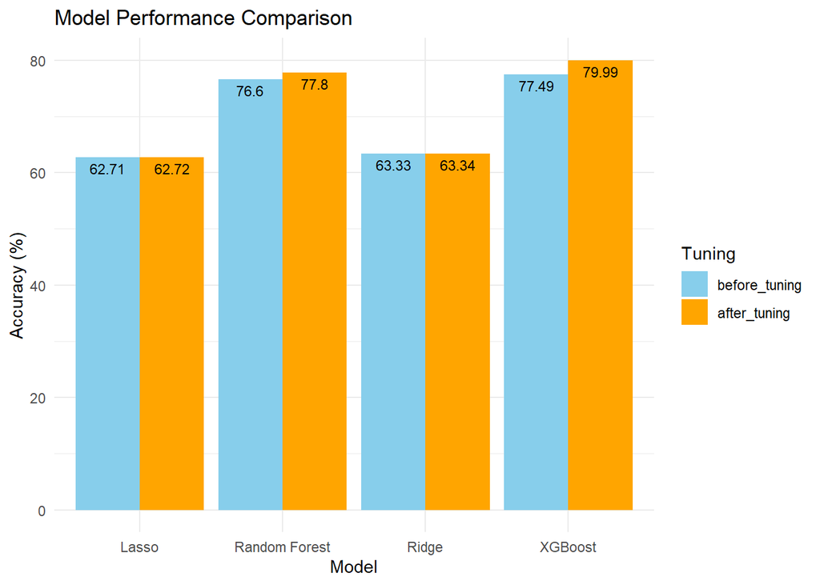

```r
if (!require("ggplot2")) install.packages("ggplot2")
library(ggplot2)
models <- c('Lasso', 'Ridge', 'Random Forest', 'XGBoost')
before_tuning <- c(62.71, 63.33, 76.6, 77.49)
after_tuning <- c(62.72, 63.34, 77.8, 79.99)
data <- data.frame(models, before_tuning, after_tuning)
long_data <- reshape2::melt(data, id.vars = 'models', variable.name = 'tuning', value.name = 'r_squared')
ggplot(long_data, aes(x = models, y = r_squared, fill = tuning)) +
  geom_bar(stat = 'identity', position = 'dodge') +
  scale_fill_manual(values = c('skyblue', 'orange')) +
  theme_minimal() +
  labs(title = 'Model Performance Comparison',
       x = 'Model',
       y = 'Accuracy (%)',
       fill = 'Tuning') +
  geom_text(aes(label = r_squared), vjust = 1.5, color = "black", position = position_dodge(0.9), size = 3)
```